# STAT385 HW0

Danny Yoon, syoon46

September 5, 2017

## Exercise 1: Know Thine Environment

- **R 3.4.1**

```r
R.Version()$version.string
```

```
## [1] "R version 3.4.1 (2017-06-30)"
```

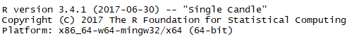

- **RStudio 1.0.153**

```r
#RStudio.version()
```

[figure not shown]

- **Git**

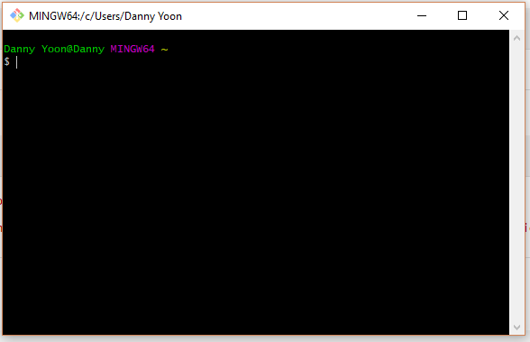

- **R Build Toolchain**

```r
#Rcpp::evalCpp("2+2") == 4
```

[output not shown]

- **Slack**

[figure not shown]

- **Verification of Working R Install**

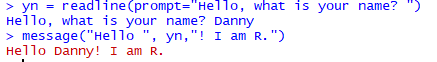

## Exercise 2: Toto, I have a feeling we’re not in Kansas anymore…

1. James Balamuta
2. Tech Plaza 212F, Tuesday & Thursday, 9:00 – 10:00 AM, Room G36 of the Foreign Language Building (FLB)
4. 218 Mechanical Engineering Bldg, Monday, Wednesday, and Friday, 2:00 PM - 2:50 PM
5. One midterm and one final exam, dates are not up yet.
6. Each component is worth 100 which makes 400 points total. Peer evaluations of group memebers may influence the gradse of students.
7. It is allowed to help each other but all the code shuold be typed by each student, not copy and pasted.

**R 3.4.1**

**RStudio 1.0.153**

**Git**

**R Build Toolchain**

**Slack**